# Stats in Python

```python
import math
import numpy as np
from scipy import stats
import matplotlib.pyplot as plt
#from statistics import stdev #for samples, not pop. ((n-1) not n)
%matplotlib inline
```

```python
#!pip install --upgrade scipy
```

```python
print(dir(math))
```

[output not shown]

```python
print(dir(np))
```

[output not shown]

Calculate the mean, median, mode and standard deviation for the problem statements 1 & 2.

Problem Statement 1: The marks awarded for an assignment set for a Year 8 class of 20 students were as follows: 6 7 5 7 7 8 7 6 9 7 4 10 6 8 8 9 5 6 4 8

```python
class_of_students = np.array([6, 7, 5, 7, 7, 8, 7, 6, 9, 7, 4, 10, 6, 8, 8, 9, 5, 6, 4, 8])
```

```python
mean_students = np.mean(class_of_students)
median_students = np.median(class_of_students)
mode_students = stats.mode(class_of_students).mode
sd_students = np.std(class_of_students)
```

```python
print(f'mean: {mean_students}, median: {median_students}, mode: {mode_students}, standard deviation: {sd_students}')
```

```
mean: 6.85, median: 7.0, mode: 7, standard deviation: 1.5898113095584647
```

Problem Statement 2: The number of calls from motorists per day for roadside service was recorded for a particular month: 28, 122, 217, 130, 120, 86, 80, 90, 140, 120, 70, 40, 145, 113, 90, 68, 174, 194, 170, 100, 75, 104, 97, 75, 123, 100, 75, 104, 97, 75, 123, 100, 89, 120, 109

```python
num_motorist_calls = np.array([28, 122, 217, 130, 120, 86, 80, 90, 140, 120, 70, 40, 145, 113, 90, 68, 174, 194, 170, 100, 75, 104, 97, 75, 123, 100, 75, 104, 97, 75, 123, 100, 89, 120, 109])
```

```python
mean_motorist_calls = np.mean(num_motorist_calls)
median_motorist_calls = np.median(num_motorist_calls)
mode_motorist_calls = stats.mode(num_motorist_calls).mode
sd_motorist_calls = np.std(num_motorist_calls)
```

```python
print(f'mean: {mean_motorist_calls}, median: {median_motorist_calls}, mode: {mode_motorist_calls}, standard deviation: {sd_motorist_calls}')
```

```
mean: 107.51428571428572, median: 100.0, mode: 75, standard deviation: 38.77287080168403
```

Problem Statement 3: The number of times I go to the gym in weekdays, are given below along with its associated probability: x = 0, 1, 2, 3, 4, 5 f(x) = 0.09, 0.15, 0.40, 0.25, 0.10, 0.01 Calculate the mean no. of workouts in a week. Also evaluate the variance involved in it.

```python
num_workouts = np.array([0, 1, 2, 3, 4, 5])
workout_probs = np.array([0.09, 0.15, 0.40, 0.25, 0.10, 0.01])
```

```python
mean_workouts = sum(num_workouts * workout_probs)
```

```python
mean_workouts
```

```
2.15
```

```python
#https://www.statology.org/variance-of-probability-distribution/
variances = np.array([((num_workouts[i] - mean_workouts)**2)*workout_probs[i] for i in range(len(num_workouts))])
variance_workouts = sum(variances)
```

```python
variance_workouts
```

```
1.2275
```

```python
print(f'mean: {mean_workouts}, variance: {variance_workouts}')
```

```
mean: 2.15, variance: 1.2275
```

Problem Statement 4: Let the continuous random variable D denote the diameter of the hole drilled in an aluminum sheet. The target diameter to be achieved is 12.5mm. Random disturbances in the process often result in inaccuracy. Historical data shows that the distribution of D can be modelled by the PDF (𝑑) = 20𝑒−20(𝑑−12.5), 𝑑 ≥ 12.5. If a part with diameter > 12.6 mm needs to be scrapped, what is the proportion of those parts? What is the CDF when the diameter is of 11 mm? What is your conclusion regarding the proportion of scraps?

```python
#continuous
d_lst1 = np.arange(12.5, 15, 0.1)
```

```python
d_lst1
```

```
array([12.5, 12.6, 12.7, 12.8, 12.9, 13. , 13.1, 13.2, 13.3, 13.4, 13.5,
       13.6, 13.7, 13.8, 13.9, 14. , 14.1, 14.2, 14.3, 14.4, 14.5, 14.6,
       14.7, 14.8, 14.9])
```

```python
pdf1 = 20*math.e**(-20*(d_lst1-12.5))
pdf1
```

```
array([2.00000000e+01, 2.70670566e+00, 3.66312778e-01, 4.95750435e-02,
       6.70925256e-03, 9.07998595e-04, 1.22884247e-04, 1.66305744e-05,
       2.25070349e-06, 3.04599595e-07, 4.12230724e-08, 5.57893619e-09,
       7.55026909e-10, 1.02181781e-10, 1.38288002e-11, 1.87152459e-12,
       2.53283311e-13, 3.42781686e-14, 4.63904566e-15, 6.27826558e-16,
       8.49670851e-17, 1.14990445e-17, 1.55622645e-18, 2.10612347e-19,
       2.85032817e-20])
```

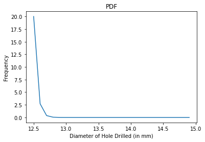

```python
plt.plot(d_lst1, pdf1)
plt.title('PDF')
plt.xlabel("Diameter of Hole Drilled (in mm)")
plt.ylabel("Frequency")
plt.show()
```

```python
cdf1 = 1 - math.e**(-20*(d_lst1-12.5))
cdf1
```

```
array([0.        , 0.86466472, 0.98168436, 0.99752125, 0.99966454,
       0.9999546 , 0.99999386, 0.99999917, 0.99999989, 0.99999998,
       1.        , 1.        , 1.        , 1.        , 1.        ,
       1.        , 1.        , 1.        , 1.        , 1.        ,
       1.        , 1.        , 1.        , 1.        , 1.        ])
```

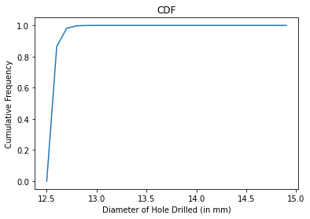

```python
plt.plot(d_lst1, cdf1)
plt.title('CDF')
plt.xlabel("Diameter of Hole Drilled (in mm)")
plt.ylabel("Cumulative Frequency")
plt.show()
```

```python
percentage_parts_scrapped = round((1 - cdf1[1]) * 100, 2)
print(f'~{percentage_parts_scrapped}% of parts need to be scrapped given > 12.6mm not allowed!')
```

```
~13.53% of parts need to be scrapped given > 12.6mm not allowed!
```

```python
print("Since 11mm is less than 12.5mm (constraint of pdf), the cdf of 11mm, or cdf(d=11), is 0.")
```

```
Since 11mm is less than 12.5mm (constraint of pdf), the cdf of 11mm, or cdf(d=11), is 0.
```